# Evaluating bias and variance across different validation methods for disease simulation models

## Optimism

- SAMPLE from POPULATION of interest
- Fit model in SAMPLE
- Optimism = AUC – AUC

## Optimism correction

### Split sample

- Split TRAIN and TEST
- Fit model in TRAIN
- Calculate optimism-corrected AUC from AUC

## Optimism correction

### Cross-validation

- Split TRAIN and TEST
- Fit model in TRAIN
- Calculate optimism-corrected AUC from AUC
- Reverse and repeat
- Calculate optimism-corrected AUC as the average performance on the different TEST sets

## Optimism correction

### Bootstrap

- Fit model on SAMPLE and calculate AUC
- Draw BOOTSTRAP SAMPLE from SAMPLE
- Fit model in BOOTSTRAP SAMPLE
- Apply model on SAMPLE
- Optimism = AUC – AUC
- Repeat 100 times
- Calculate optimism-corrected AUC from AUC - mean(**Optimism**)

## Microsimulation

- Used in economics, public and population health
- Use individual-level data to construct a group of individuals to represent a target population and their behaviours
- Simulates, using known probabilities, changes in individual’s characteristics over time
- Tracks the changing behaviour inside a dynamic model as the environment and individual change over time

## Paper

### Setup

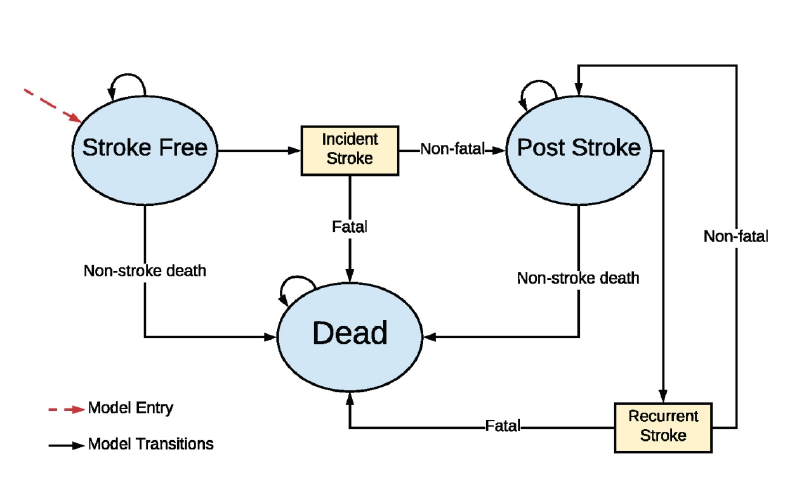

[figure not shown]

## Paper

### Setup

- Data from Atherosclerosis Risk in Communities (ARIC) study
- 15,792 participants aged 45-64 recruited from 1987-1989
- Mean follow-up time 22.8 years
- Data contains information on:
  - common risk factors (age, sex, blood pressure, …)
  - stroke incidence
  - death

## Paper

### Setup

- Use the data from ARIC to build a microsimulation model
- Draw 1000 individuals from ARIC
- Use the transition probabilities from the ARIC microsimulation model to simualate state changes
- Develop a prediction model for stroke mortality
- Evaluate performance correcting for optimism
- Validate model in a simulated dataset of 100,000 individuals to get “true” performance
- Repeat 1000 times

## Paper

### Results: base case

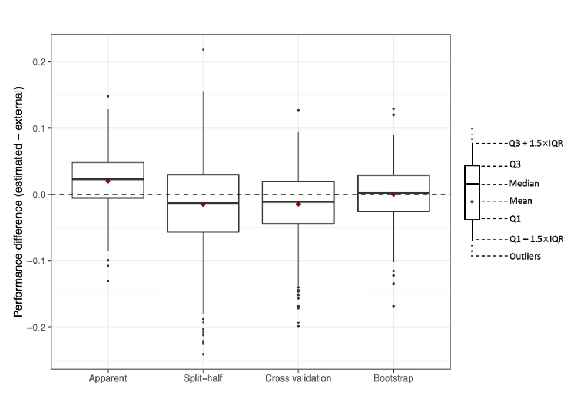

## Paper

### Results: sample size

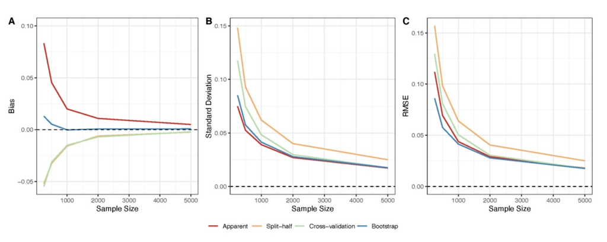

## Paper

### Results: cross validation

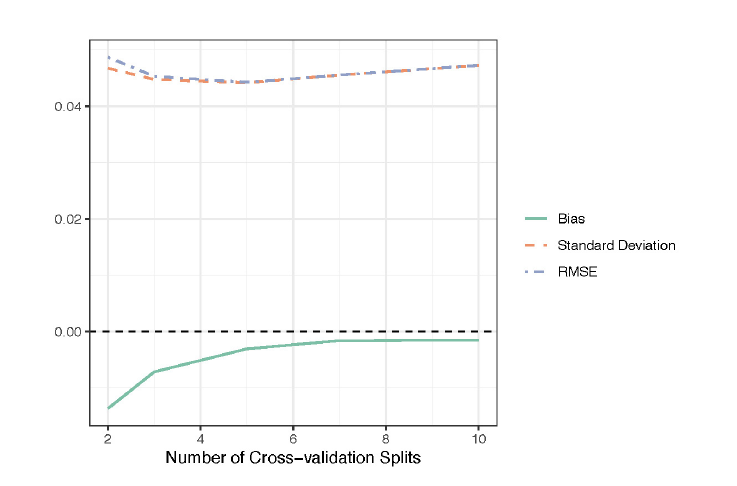

## Paper

### Conclusions

- Apparent performance is optimistic
- Split sample and cross validation pessimistic
- Bootstrap is better alternative, but computationally intensive (often infeasible?)